# CS 108 Statistics — Project 1

2026-09-27

```
{r setup, include=FALSE}
knitr::opts_chunk$set(echo = TRUE, warning = FALSE, message = FALSE,
                      fig.width = 8, fig.height = 5)
```

# 1. Dataset Description

**Source.** NASA Exoplanet Archive, *Planetary Systems* (PS) table ([link](https://exoplanetarchive.ipac.caltech.edu/cgi-bin/TblView/nph-tblView?app=ExoTbls&config=PS); Akeson et al. 2013). The archive collects published parameters of confirmed exoplanets from the literature.

**Observation.** One row of the raw table is one *published parameter set* for one planet, so a planet can appear many times. We keep the row marked `default_flag = 1`, so in the analysed data **one observation = one confirmed planet** (its default parameter set). **Context.** All confirmed exoplanets known to the archive, i.e. planets that were *detectable*, not a random sample of all planets.

| Variable | Meaning | Unit / type |
| --- | --- | --- |
| `discoverymethod` | detection technique | categorical |
| `sy_snum` | number of stars in the host system | count → categorical |
| `disc_year` | year of discovery | year → period (`disc_era`) |
| `ttv_flag`, `pl_controv_flag` | transit timing variations detected; controversial planet | 0/1 |
| `pl_rade`, `pl_bmasse` | planet radius, planet (best) mass | Earth radii, Earth masses |
| `pl_orbper`, `pl_orbsmax` | orbital period, semi-major axis | days, AU |
| `pl_eqt` | equilibrium temperature (*calculated*, not measured) | K |
| `st_teff`, `st_mass` | host star effective temperature, mass | K, solar masses |

# 2 Data Preparation

## 2.1 Data Import and Structure Examination

```r
library(readr)
library(ggplot2)
library(dplyr)
library(tidyr)
library(scales)
exo <- read_csv("ExoplanetsDataset.csv", comment = "#",  show_col_types = FALSE)
dim(exo)
```

```
## [1] 40155    92
```

```r
names(exo)
```

```
##  [1] "pl_name"         "hostname"        "default_flag"    "sy_snum"
##  [5] "sy_pnum"         "discoverymethod" "disc_year"       "disc_facility"
##  [9] "soltype"         "pl_controv_flag" "pl_refname"      "pl_orbper"
## [13] "pl_orbpererr1"   "pl_orbpererr2"   "pl_orbperlim"    "pl_orbsmax"
## [17] "pl_orbsmaxerr1"  "pl_orbsmaxerr2"  "pl_orbsmaxlim"   "pl_rade"
## [21] "pl_radeerr1"     "pl_radeerr2"     "pl_radelim"      "pl_radj"
## [25] "pl_radjerr1"     "pl_radjerr2"     "pl_radjlim"      "pl_bmasse"
## [29] "pl_bmasseerr1"   "pl_bmasseerr2"   "pl_bmasselim"    "pl_bmassj"
## [33] "pl_bmassjerr1"   "pl_bmassjerr2"   "pl_bmassjlim"    "pl_bmassprov"
## [37] "pl_orbeccen"     "pl_orbeccenerr1" "pl_orbeccenerr2" "pl_orbeccenlim"
## [41] "pl_insol"        "pl_insolerr1"    "pl_insolerr2"    "pl_insollim"
## [45] "pl_eqt"          "pl_eqterr1"      "pl_eqterr2"      "pl_eqtlim"
## [49] "ttv_flag"        "st_refname"      "st_spectype"     "st_teff"
## [53] "st_tefferr1"     "st_tefferr2"     "st_tefflim"      "st_rad"
## [57] "st_raderr1"      "st_raderr2"      "st_radlim"       "st_mass"
## [61] "st_masserr1"     "st_masserr2"     "st_masslim"      "st_met"
## [65] "st_meterr1"      "st_meterr2"      "st_metlim"       "st_metratio"
## [69] "st_logg"         "st_loggerr1"     "st_loggerr2"     "st_logglim"
## [73] "sy_refname"      "rastr"           "ra"              "decstr"
## [77] "dec"             "sy_dist"         "sy_disterr1"     "sy_disterr2"
## [81] "sy_vmag"         "sy_vmagerr1"     "sy_vmagerr2"     "sy_kmag"
## [85] "sy_kmagerr1"     "sy_kmagerr2"     "sy_gaiamag"      "sy_gaiamagerr1"
## [89] "sy_gaiamagerr2"  "rowupdate"       "pl_pubdate"      "releasedate"
```

```r
str(exo)
```

```
## spc_tbl_ [40,155 × 92] (S3: spec_tbl_df/tbl_df/tbl/data.frame)
##  $ pl_name        : chr [1:40155] "11 Com b" "11 Com b" "11 Com b" "11 UMi b" ...
##  $ hostname       : chr [1:40155] "11 Com" "11 Com" "11 Com" "11 UMi" ...
##  $ default_flag   : num [1:40155] 0 1 0 1 0 0 1 0 0 0 ...
##  $ sy_snum        : num [1:40155] 2 2 2 1 1 1 1 1 1 1 ...
##  $ sy_pnum        : num [1:40155] 1 1 1 1 1 1 1 1 1 2 ...
##  $ discoverymethod: chr [1:40155] "Radial Velocity" "Radial Velocity" "Radial Velocity" "Radial Velocity" ...
##  $ disc_year      : num [1:40155] 2007 2007 2007 2009 2009 ...
##  $ disc_facility  : chr [1:40155] "Xinglong Station" "Xinglong Station" "Xinglong Station" "Thueringer Landessternwarte Tautenburg" ...
##  $ soltype        : chr [1:40155] "Published Confirmed" "Published Confirmed" "Published Confirmed" "Published Confirmed" ...
##  $ pl_controv_flag: num [1:40155] 0 0 0 0 0 0 0 0 0 0 ...
##  $ pl_refname     : chr [1:40155] "<a refstr=KUNITOMO_ET_AL__2011 href=https://ui.adsabs.harvard.edu/abs/2011ApJ...737...66K/abstract target=ref> "| __truncated__ "<a refstr=TENG_ET_AL_2023 href=https://ui.adsabs.harvard.edu/abs/2023PASJ...75.1030T/abstract target=ref>Teng et al. 2023</a>" "<a re…
##  $ pl_orbper      : num [1:40155] NA 323 326 516 NA ...
##  $ pl_orbpererr1  : num [1:40155] NA 0.06 0.32 3.2 NA 3.25 0.11 0.23 NA 50 ...
##  $ pl_orbpererr2  : num [1:40155] NA -0.05 -0.32 -3.2 NA -3.25 -0.12 -0.23 NA -50 ...
##  $ pl_orbperlim   : num [1:40155] NA 0 0 0 NA 0 0 0 NA 0 ...
##  $ pl_orbsmax     : num [1:40155] 1.21 1.18 1.29 1.53 1.51 ...
##  $ pl_orbsmaxerr1 : num [1:40155] 0.06 0 0.05 0.07 0.06 0.07 0 NA 0.03 NA ...
##  $ pl_orbsmaxerr2 : num [1:40155] -0.05 0 -0.05 -0.07 -0.05 -0.07 0 NA -0.06 NA ...
##  $ pl_orbsmaxlim  : num [1:40155] 0 0 0 0 0 0 0 0 0 0 ...
##  $ pl_rade        : num [1:40155] NA NA NA NA NA NA NA NA NA NA ...
##  $ pl_radeerr1    : num [1:40155] NA NA NA NA NA NA NA NA NA NA ...
##  $ pl_radeerr2    : num [1:40155] NA NA NA NA NA NA NA NA NA NA ...
##  $ pl_radelim     : num [1:40155] NA NA NA NA NA NA NA NA NA NA ...
##  $ pl_radj        : num [1:40155] NA NA NA NA NA NA NA NA NA NA ...
##  $ pl_radjerr1    : num [1:40155] NA NA NA NA NA NA NA NA NA NA ...
##  $ pl_radjerr2    : num [1:40155] NA NA NA NA NA NA NA NA NA NA ...
##  $ pl_radjlim     : num [1:40155] NA NA NA NA NA NA NA NA NA NA ...
##  $ pl_bmasse      : num [1:40155] 5435 4915 6166 4685 3432 ...
##  $ pl_bmasseerr1  : num [1:40155] 540.3 39.1 476.7 794.6 381.4 ...
##  $ pl_bmasseerr2  : num [1:40155] -413.2 -39.7 -476.7 -794.6 -413.2 ...
##  $ pl_bmasselim   : num [1:40155] 0 0 0 0 0 0 0 0 0 0 ...
##  $ pl_bmassj      : num [1:40155] 17.1 15.5 19.4 14.7 10.8 ...
##  $ pl_bmassjerr1  : num [1:40155] 1.7 0.123 1.5 2.5 1.2 2.47 0.114 NA 0.4 NA ...
##  $ pl_bmassjerr2  : num [1:40155] -1.3 -0.125 -1.5 -2.5 -1.3 -2.47 -0.122 NA -0.6 NA ...
##  $ pl_bmassjlim   : num [1:40155] 0 0 0 0 0 0 0 0 0 0 ...
##  $ pl_bmassprov   : chr [1:40155] "Msini" "Msini" "Msini" "Msini" ...
##  $ pl_orbeccen    : num [1:40155] NA 0.238 0.231 0.08 NA 0.08 0 0 NA 0.37 ...
##  $ pl_orbeccenerr1: num [1:40155] NA 0.007 0.005 0.03 NA 0.03 NA NA NA 0.04 ...
##  $ pl_orbeccenerr2: num [1:40155] NA -0.007 -0.005 -0.03 NA -0.03 NA NA NA -0.04 ...
```

[output cut: 134 more lines]

[output not shown]

## 2.2 Missing Values, Inconsistencies, and Unusual Observations

- **Missing Value Analysis**: The missing-value analysis showed that the completeness of variables differs substantially. Orbital period has fewer missing values than several physical properties such as planet mass and radius. Because missingness varies across variables, analyses involving these variables use only observations for which the required variables are available.

```r
key_vars <- c(
  "pl_rade",
  "pl_orbper",
  "pl_bmasse",
  "pl_orbsmax",
  "discoverymethod",
  "sy_snum"
)

missing_summary <- data.frame(
  Variable = key_vars,
  Missing = sapply(exo[key_vars], function(x) sum(is.na(x))),
  Missing_Percent = round(
    sapply(exo[key_vars], function(x) mean(is.na(x))) * 100, 2
  )
)

missing_summary
```

```
##                        Variable Missing Missing_Percent
## pl_rade                 pl_rade   12497           31.12
## pl_orbper             pl_orbper    3420            8.52
## pl_bmasse             pl_bmasse   32558           81.08
## pl_orbsmax           pl_orbsmax   17764           44.24
## discoverymethod discoverymethod       0            0.00
## sy_snum                 sy_snum       0            0.00
```

- **Data Integrity Checks**: Sanity checks confirmed that physical attributes contain no non-physical zero or negative values.

```r
sum(exo$pl_rade <= 0, na.rm = TRUE)
```

```
## [1] 0
```

```r
sum(exo$pl_orbper <= 0, na.rm = TRUE)
```

```
## [1] 0
```

```r
sum(exo$pl_bmasse <= 0, na.rm = TRUE)
```

```
## [1] 0
```

```r
sum(exo$pl_orbsmax <= 0, na.rm = TRUE)
```

```
## [1] 0
```

- **Handling Duplicate Entries**: The primary Planetary Systems table contains multiple published parameter sets for single planets across different scientific papers. Filtering by default_flag == 1 isolates the single default, peer-reviewed parameter set for each distinct exoplanet, preventing duplicate weighting in subsequent EDA steps.

```r
sum(exo$default_flag == 1, na.rm = TRUE)
```

```
## [1] 6366
```

## 2.3 Data Type Conversions and Explicit Explanations

Categorical variables were stored as character or integer types, so they were converted to factors. Two derived categorical variables were also created. No observations were removed in this step.

- `discoverymethod` -> factor.
- `disc_method_cat`: the four most frequent discovery methods are kept and all others are merged into “Other”. This makes plots readable, but “Other” mixes several detection techniques and must not be read as one method.
- `sy_snum` -> `snum_cat` with levels Single Star (1), Binary Star System (2), Multi-Star (3+). The 3+ levels are merged because they are rare.
- `disc_year` -> `disc_era` (four time periods), so the discovery year can be treated as a categorical variable.
- `ttv_flag`, `pl_controv_flag` (0/1) -> factors with labels “No”/“Yes”.

```r
exo_clean <- exo %>% filter(default_flag == 1)   # one parameter set per planet

top_methods <- exo_clean %>%
  count(discoverymethod) %>%
  slice_max(n, n = 4, with_ties = FALSE) %>%
  pull(discoverymethod)

exo_clean <- exo_clean %>%
  mutate(
    discoverymethod = factor(discoverymethod),
    disc_method_cat = factor(ifelse(discoverymethod %in% top_methods,
                                    as.character(discoverymethod), "Other")),
    snum_cat = factor(case_when(
      sy_snum == 1 ~ "Single Star",
      sy_snum == 2 ~ "Binary Star System",
      sy_snum >= 3 ~ "Multi-Star (3+)"),
      levels = c("Single Star", "Binary Star System", "Multi-Star (3+)")),
    disc_era = cut(disc_year,
                   breaks = c(-Inf, 2009, 2014, 2019, Inf),
                   labels = c("Before 2010", "2010-2014", "2015-2019", "2020 onward")),
    ttv_flag = factor(ttv_flag, levels = c(0, 1), labels = c("No", "Yes")),
    pl_controv_flag = factor(pl_controv_flag, levels = c(0, 1), labels = c("No", "Yes"))
  )

nrow(exo_clean)   # number of distinct planets analysed
```

```
## [1] 6366
```

# 3. Analysis of Categorical Variables

The important categorical variables are the discovery method, the number of stars in the system, the discovery period, and the transit-timing-variation (TTV) flag. Each unit of observation is one planet (default parameter set).

## 3.1 Discovery Method (`discoverymethod`)

```r
tab_method <- table(exo_clean$discoverymethod)
method_df <- data.frame(
  Method = names(tab_method),
  Frequency = as.integer(tab_method),
  Relative_Freq = round(as.numeric(prop.table(tab_method)), 4),
  Percent = round(100 * as.numeric(prop.table(tab_method)), 2)
) %>% arrange(desc(Frequency))

knitr::kable(method_df, caption = "Frequency and relative frequency of discovery methods")
```

Frequency and relative frequency of discovery methods

| Method | Frequency | Relative_Freq | Percent |
| --- | --- | --- | --- |
| Transit | 4708 | 0.7396 | 73.96 |
| Radial Velocity | 1200 | 0.1885 | 18.85 |
| Microlensing | 289 | 0.0454 | 4.54 |
| Imaging | 97 | 0.0152 | 1.52 |
| Transit Timing Variations | 29 | 0.0046 | 0.46 |
| Eclipse Timing Variations | 17 | 0.0027 | 0.27 |
| Orbital Brightness Modulation | 9 | 0.0014 | 0.14 |
| Pulsar Timing | 8 | 0.0013 | 0.13 |
| Astrometry | 6 | 0.0009 | 0.09 |
| Pulsation Timing Variations | 2 | 0.0003 | 0.03 |
| Disk Kinematics | 1 | 0.0002 | 0.02 |

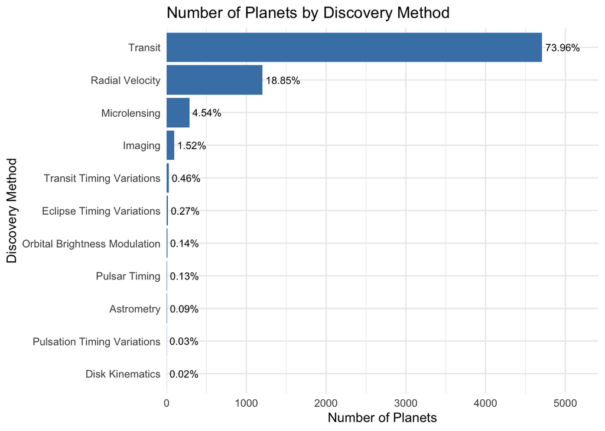

```r
ggplot(method_df, aes(x = reorder(Method, Frequency), y = Frequency)) +
  geom_col(fill = "steelblue") +
  geom_text(aes(label = paste0(Percent, "%")), hjust = -0.1, size = 3) +
  coord_flip() +
  scale_y_continuous(expand = expansion(mult = c(0, 0.15))) +
  labs(title = "Number of Planets by Discovery Method",
       x = "Discovery Method", y = "Number of Planets") +
  theme_minimal()
```

**Interpretation.** The distribution is far from balanced. The Transit method is by far the most common and accounts for 73.96% of all planets, followed by Radial Velocity 18.85%. Several methods (for example Microlensing, Imaging, Transit Timing Variations, Eclipse Timing Variations, Orbital Brightness Modulation, Astrometry, Pulsar Timing, Pulsation Timing Variations, Disk Kinematics) are rare, each representing only a few planets or a small fraction of the data. Such sparse categories are potentially problematic: summaries based on a handful of planets are unstable, and tables or tests involving them are unreliable. For this reason, the four most frequent methods are kept as separate categories and all others are combined into “Other” in later sections.

```r
tab_cat <- table(exo_clean$disc_method_cat)
knitr::kable(
  data.frame(Category = names(tab_cat),
             Frequency = as.integer(tab_cat),
             Percent = round(100 * as.numeric(prop.table(tab_cat)), 2)),
  caption = "Discovery method after grouping (top 4 + Other)")
```

Discovery method after grouping (top 4 + Other)

| Category | Frequency | Percent |
| --- | --- | --- |
| Imaging | 97 | 1.52 |
| Microlensing | 289 | 4.54 |
| Other | 72 | 1.13 |
| Radial Velocity | 1200 | 18.85 |
| Transit | 4708 | 73.96 |

## 3.2 Number of Stars in the System (`snum_cat`)

```r
tab_snum <- table(exo_clean$snum_cat, useNA = "ifany")
snum_df <- data.frame(
  Category = names(tab_snum),
  Frequency = as.integer(tab_snum),
  Percent = round(100 * as.numeric(prop.table(tab_snum)), 2)
)
knitr::kable(snum_df, caption = "Stellar multiplicity of the host systems")
```

Stellar multiplicity of the host systems

| Category | Frequency | Percent |
| --- | --- | --- |
| Single Star | 5789 | 90.94 |
| Binary Star System | 502 | 7.89 |
| Multi-Star (3+) | 75 | 1.18 |

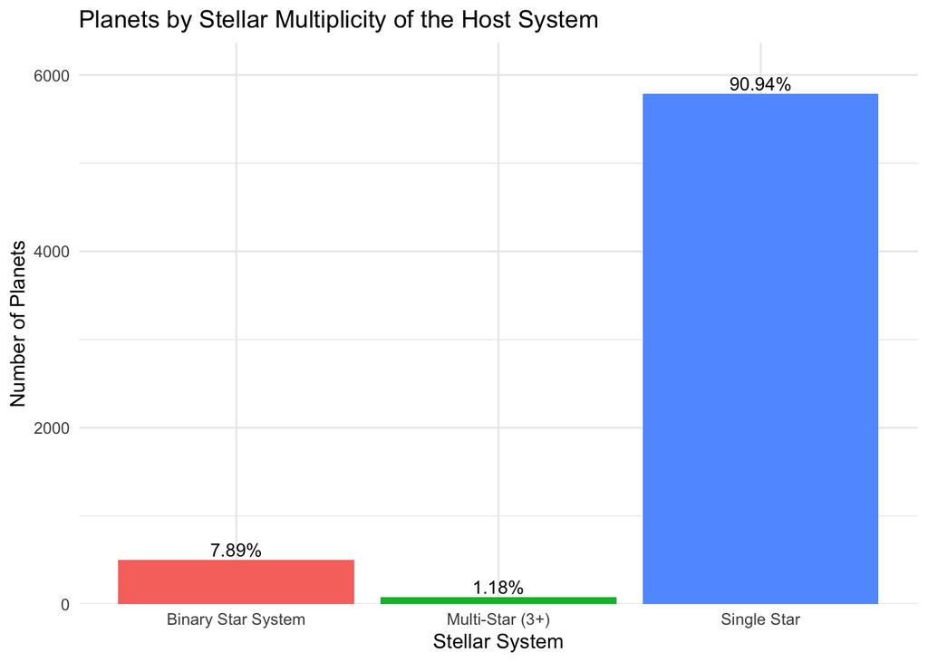

```r
ggplot(snum_df, aes(x = Category, y = Frequency, fill = Category)) +
  geom_col(show.legend = FALSE) +
  geom_text(aes(label = paste0(Percent, "%")), vjust = -0.3, size = 3.5) +
  scale_y_continuous(expand = expansion(mult = c(0, 0.1))) +
  labs(title = "Planets by Stellar Multiplicity of the Host System",
       x = "Stellar System", y = "Number of Planets") +
  theme_minimal()
```

**Interpretation.** Most planets in the archive orbit single stars, 90.94%, while binary systems make up 7.89% and systems with three or more stars only 1.18%. The Multi-Star category is rare, so any comparison involving it is less reliable. Part of this imbalance may reflect observational selection: surveys often favour single stars because companion stars complicate detection.

## 3.3 Discovery Period (`disc_era`)

```r
tab_era <- table(exo_clean$disc_era, useNA = "ifany")
era_df <- data.frame(
  Period = names(tab_era),
  Frequency = as.integer(tab_era),
  Percent = round(100 * as.numeric(prop.table(tab_era)), 2)
)
knitr::kable(era_df, caption = "Planets by discovery period")
```

Planets by discovery period

| Period | Frequency | Percent |
| --- | --- | --- |
| Before 2010 | 405 | 6.36 |
| 2010-2014 | 1378 | 21.65 |
| 2015-2019 | 2313 | 36.33 |
| 2020 onward | 2270 | 35.66 |

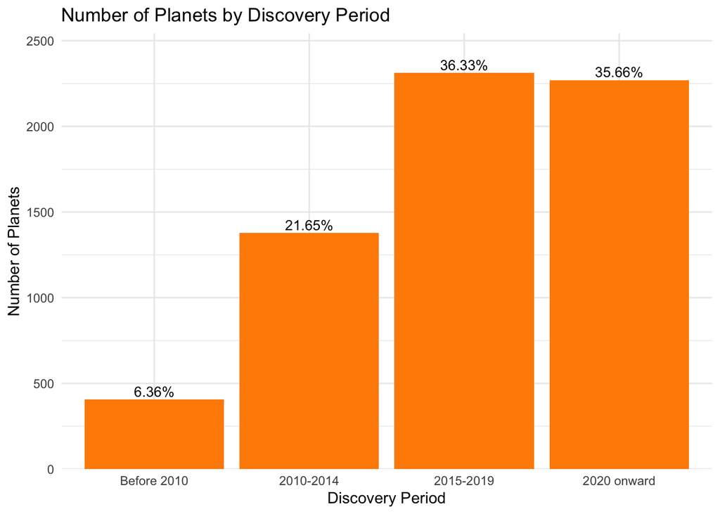

```r
ggplot(era_df, aes(x = factor(Period, levels = levels(exo_clean$disc_era)), y = Frequency)) +
  geom_col(fill = "darkorange") +
  geom_text(aes(label = paste0(Percent, "%")), vjust = -0.3, size = 3.5) +
  scale_y_continuous(expand = expansion(mult = c(0, 0.1))) +
  labs(title = "Number of Planets by Discovery Period",
       x = "Discovery Period", y = "Number of Planets") +
  theme_minimal()
```

**Interpretation.** The number of discoveries increased sharply over time: 93.64% of planets were found after 2010, compared with only 6.36% before 2010. The distribution is therefore strongly unbalanced toward recent years, which reflects the growth of large survey missions.

## 3.4 Transit Timing Variations (`ttv_flag`)

```r
tab_ttv <- table(exo_clean$ttv_flag, useNA = "ifany")
knitr::kable(
  data.frame(TTV = names(tab_ttv),
             Frequency = as.integer(tab_ttv),
             Percent = round(100 * as.numeric(prop.table(tab_ttv)), 2)),
  caption = "Planets with detected transit timing variations")
```

Planets with detected transit timing variations

| TTV | Frequency | Percent |
| --- | --- | --- |
| No | 5864 | 92.11 |
| Yes | 494 | 7.76 |
| NA | 8 | 0.13 |

**Interpretation.** Only 7.76% planets show TTVs, so this is a heavily imbalanced binary variable. It is mainly useful as a supplementary variable.

## 3.5 Interaction Between Categorical Variables

### Pair 1: Discovery Method and Stellar Multiplicity

*Question: does the distribution of stellar multiplicity differ between discovery methods?*

```r
ct1 <- table(exo_clean$disc_method_cat, exo_clean$snum_cat)
addmargins(ct1)
```

```
##
##                   Single Star Binary Star System Multi-Star (3+)  Sum
##   Imaging                  78                 16               3   97
##   Microlensing            278                 11               0  289
##   Other                    52                 20               0   72
##   Radial Velocity        1010                159              31 1200
##   Transit                4371                296              41 4708
##   Sum                    5789                502              75 6366
```

```r
# Row proportions: distribution of stellar multiplicity within each method
round(100 * prop.table(ct1, margin = 1), 1)
```

```
##
##                   Single Star Binary Star System Multi-Star (3+)
##   Imaging                80.4               16.5             3.1
##   Microlensing           96.2                3.8             0.0
##   Other                  72.2               27.8             0.0
##   Radial Velocity        84.2               13.2             2.6
##   Transit                92.8                6.3             0.9
```

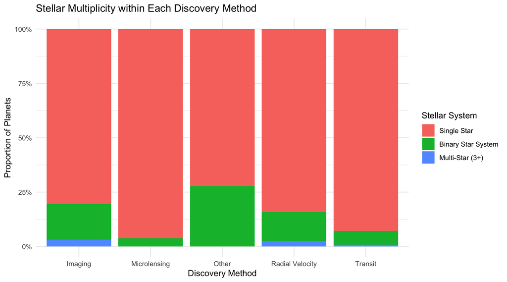

```r
df1 <- exo_clean %>% filter(!is.na(snum_cat))

ggplot(df1, aes(x = disc_method_cat, fill = snum_cat)) +
  geom_bar(position = "fill") +
  scale_y_continuous(labels = scales::percent) +
  labs(title = "Stellar Multiplicity within Each Discovery Method",
       x = "Discovery Method", y = "Proportion of Planets", fill = "Stellar System") +
  theme_minimal()
```

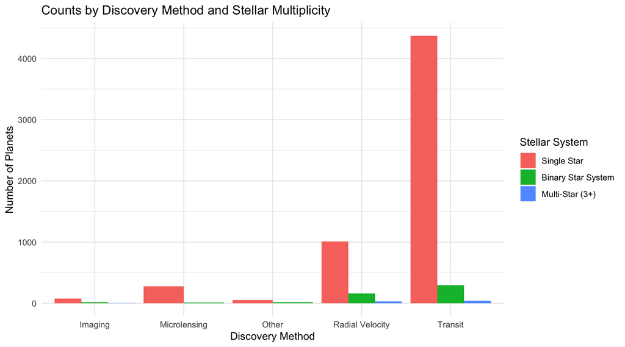

```r
ggplot(df1, aes(x = disc_method_cat, fill = snum_cat)) +
  geom_bar(position = "dodge") +
  labs(title = "Counts by Discovery Method and Stellar Multiplicity",
       x = "Discovery Method", y = "Number of Planets", fill = "Stellar System") +
  theme_minimal()
```

### Pair 2: Discovery Method and Discovery Period

*Question: has the mix of discovery methods changed over time?*

```r
ct2 <- table(exo_clean$disc_era, exo_clean$disc_method_cat)
addmargins(ct2)
```

```
##
##               Imaging Microlensing Other Radial Velocity Transit  Sum
##   Before 2010      17           10     6             312      60  405
##   2010-2014        19           21    22             207    1109 1378
##   2015-2019        17           59    13             255    1969 2313
##   2020 onward      44          199    31             426    1570 2270
##   Sum              97          289    72            1200    4708 6366
```

```r
# Row proportions: method mix within each period
round(100 * prop.table(ct2, margin = 1), 1)
```

```
##
##               Imaging Microlensing Other Radial Velocity Transit
##   Before 2010     4.2          2.5   1.5            77.0    14.8
##   2010-2014       1.4          1.5   1.6            15.0    80.5
##   2015-2019       0.7          2.6   0.6            11.0    85.1
##   2020 onward     1.9          8.8   1.4            18.8    69.2
```

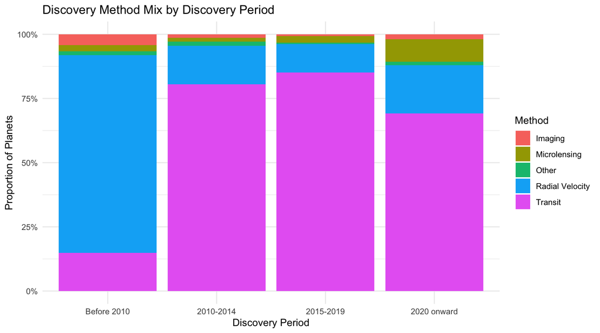

```r
df2 <- exo_clean %>% filter(!is.na(disc_era))

ggplot(df2, aes(x = disc_era, fill = disc_method_cat)) +
  geom_bar(position = "fill") +
  scale_y_continuous(labels = scales::percent) +
  labs(title = "Discovery Method Mix by Discovery Period",
       x = "Discovery Period", y = "Proportion of Planets", fill = "Method") +
  theme_minimal()
```

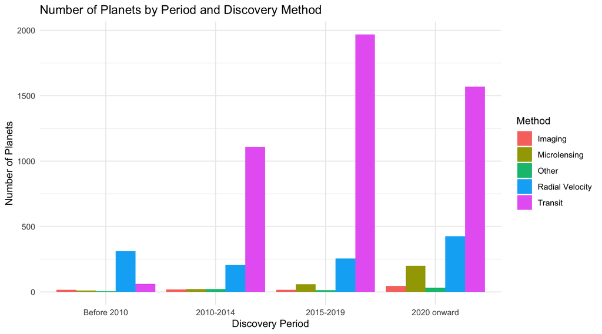

```r
ggplot(df2, aes(x = disc_era, fill = disc_method_cat)) +
  geom_bar(position = "dodge") +
  labs(title = "Number of Planets by Period and Discovery Method",
       x = "Discovery Period", y = "Number of Planets", fill = "Method") +
  theme_minimal()
```

**Interpretation.** The method mix changes clearly over time. In the earliest period, Radial Velocity dominates, whereas in later periods Transit becomes the dominant method. The distribution of one variable therefore depends strongly on the category of the other, so the two variables are clearly associated. A plausible explanation is the launch of dedicated transit surveys, but the data alone only show the association, not the reason.

# 4. Analysis of Numerical Variables

The key numerical variables are planet radius (`pl_rade`, Earth radii), planet mass (`pl_bmasse`, Earth masses), orbital period (`pl_orbper`, days), semi-major axis (`pl_orbsmax`, AU), and equilibrium temperature (`pl_eqt`, K). Missing values are excluded separately for each variable (available-case analysis), so the sample size differs between variables.

## 4.1 Descriptive Statistics

```r
num_vars <- c(
  pl_rade    = "Planet Radius (Earth radii)",
  pl_bmasse  = "Planet Mass (Earth masses)",
  pl_orbper  = "Orbital Period (days)",
  pl_orbsmax = "Semi-Major Axis (AU)",
  pl_eqt     = "Equilibrium Temperature (K)"
)

skew <- function(x) mean((x - mean(x))^3) / (mean((x - mean(x))^2))^1.5

num_summary <- function(x) {
  x <- x[!is.na(x)]
  q <- quantile(x, c(0.25, 0.75))
  fence_lo <- q[1] - 1.5 * IQR(x)
  fence_hi <- q[2] + 1.5 * IQR(x)
  data.frame(
    n = length(x), Mean = mean(x), Median = median(x),
    Min = min(x), Max = max(x), Range = max(x) - min(x),
    Q1 = q[[1]], Q3 = q[[2]], IQR = IQR(x), SD = sd(x),
    Outliers = sum(x < fence_lo | x > fence_hi),
    Outliers_pct = 100 * mean(x < fence_lo | x > fence_hi)
  )
}

summary_table <- do.call(rbind, lapply(names(num_vars), function(v) {
  cbind(Variable = num_vars[[v]], num_summary(exo_clean[[v]]))
}))

knitr::kable(summary_table, digits = 2, row.names = FALSE,
             caption = "Descriptive statistics of the key numerical variables")
```

Descriptive statistics of the key numerical variables

| Variable | n | Mean | Median | Min | Max | Range | Q1 | Q3 | IQR | SD | Outliers | Outliers_pct |
| --- | --- | --- | --- | --- | --- | --- | --- | --- | --- | --- | --- | --- |
| Planet Radius (Earth radii) | 4741 | 4.50 | 2.47 | 0.31 | 87.21 | 86.90 | 1.64 | 4.19 | 2.55 | 4.94 | 906 | 19.11 |
| Planet Mass (Earth masses) | 3158 | 766.44 | 171.24 | 0.02 | 9534.85 | 9534.83 | 12.15 | 696.04 | 683.89 | 1495.18 | 422 | 13.36 |
| Orbital Period (days) | 5994 | 4337.62 | 10.78 | 0.09 | 8040000.00 | 8039999.91 | 4.31 | 38.55 | 34.23 | 160699.62 | 1041 | 17.37 |
| Semi-Major Axis (AU) | 3926 | 20.11 | 0.12 | 0.00 | 19000.00 | 19000.00 | 0.05 | 0.84 | 0.78 | 405.02 | 606 | 15.44 |
| Equilibrium Temperature (K) | 1753 | 1001.02 | 900.00 | 50.00 | 3921.00 | 3871.00 | 573.00 | 1373.00 | 800.00 | 539.97 | 12 | 0.68 |

## 4.2 Distributions

For each variable, the histogram on the original scale, the histogram on the log10 scale, and a boxplot on the log10 scale are shown. The log scale is used because the variables span several orders of magnitude.

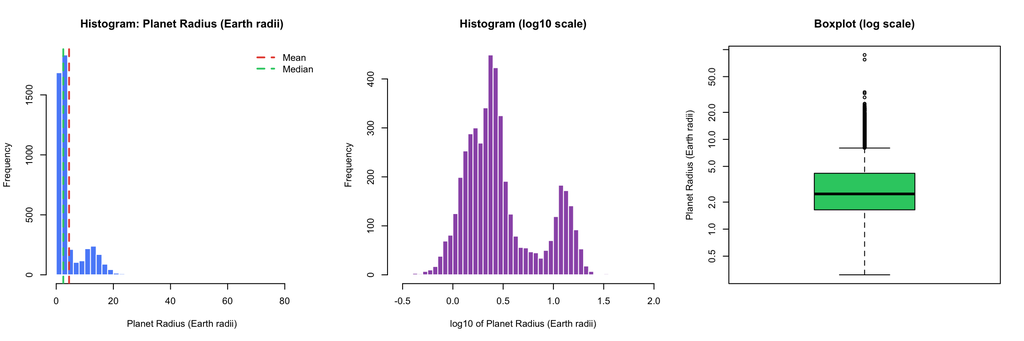

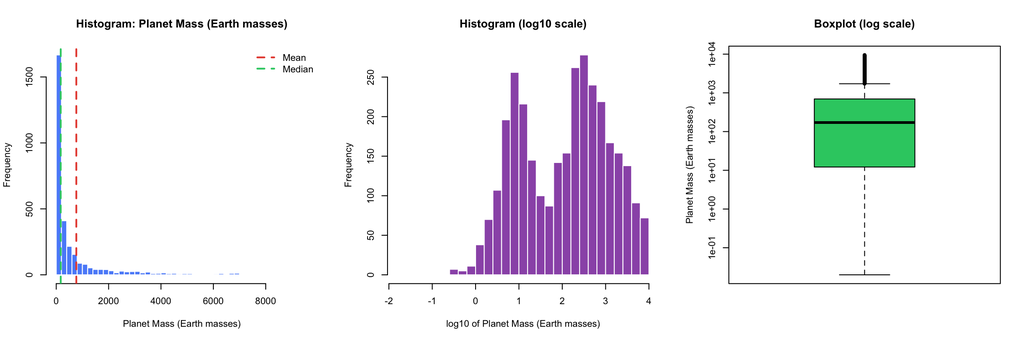

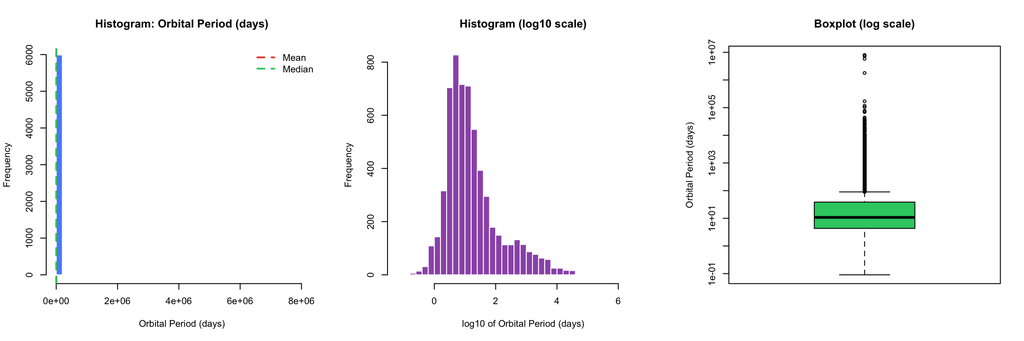

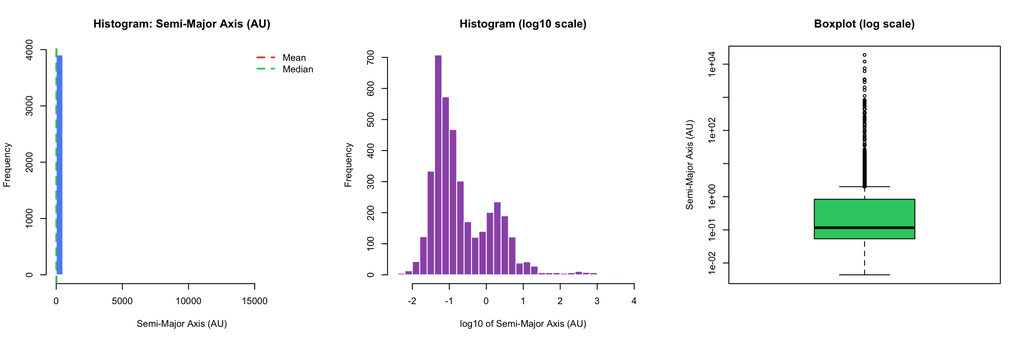

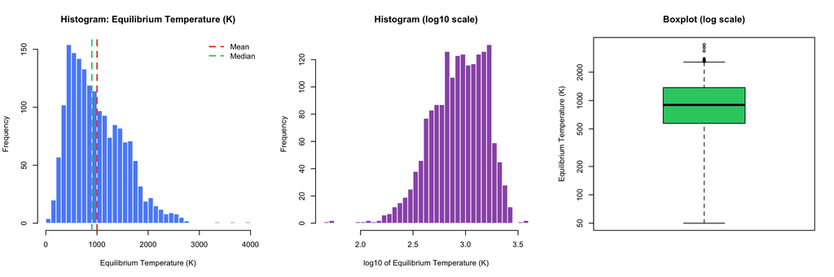

```r
for (v in names(num_vars)) {
  x <- exo_clean[[v]]
  x <- x[!is.na(x)]
  par(mfrow = c(1, 3))
  hist(x, breaks = 40, col = "#5B8FF9", border = "white",
       main = paste("Histogram:", num_vars[[v]]), xlab = num_vars[[v]])
  abline(v = c(mean(x), median(x)), col = c("#E74C3C", "#2ECC71"), lwd = 2, lty = 2)
  legend("topright", legend = c("Mean", "Median"),
         col = c("#E74C3C", "#2ECC71"), lty = 2, lwd = 2, bty = "n")
  hist(log10(x), breaks = 40, col = "#9B59B6", border = "white",
       main = "Histogram (log10 scale)", xlab = paste("log10 of", num_vars[[v]]))
  boxplot(x, log = "y", col = "#2ECC71", horizontal = FALSE,
          main = "Boxplot (log scale)", ylab = num_vars[[v]])
  par(mfrow = c(1, 1))
}
```